# R for Journalism Markdown Page

Zak Clare-Salzler

## R Markdown

This is an R Markdown page for a couple of projects from the R for Journalism MOOC offered through the Knight Center for Journalism in the Americas.

The first set of analyses and visualization shows bike use data over time for the Bay Area Bike Share program.

The second set of analyses and visualizations show a choropleth map that graphically displays the difference in the percentage of murder cases between non-white victims and white victims that are open and closed by state.

## Bay Area Bike Share data

### Load Libraries

```r
library(ggplot2)
library(tidyverse)
library(lubridate)
```

### The Analysis

This analysis will read in Bay Area bike share data and plot the median usage time for each day of the year between June 28, 2017 and December 31, 2017 for subscribers and non-subscribers or customers. A trend line with variance is plotted with the daily data.

```r
df <- read.csv('https://s3.amazonaws.com/fordgobike-data/2017-fordgobike-tripdata.csv', stringsAsFactors = F)

df <- df %>%
  mutate(duration_min = duration_sec/60)

df$start_time <- as.Date(strptime(df$start_time, format = '%Y-%m-%d'))
df$end_time <- as.Date(strptime(df$end_time, format = '%Y-%m-%d'))

df_plot <- df %>%
  group_by(user_type, start_time) %>%
  summarize(Time = median(duration_min)) %>%
  mutate(Month = month(start_time, label = T))
```

### The Plot

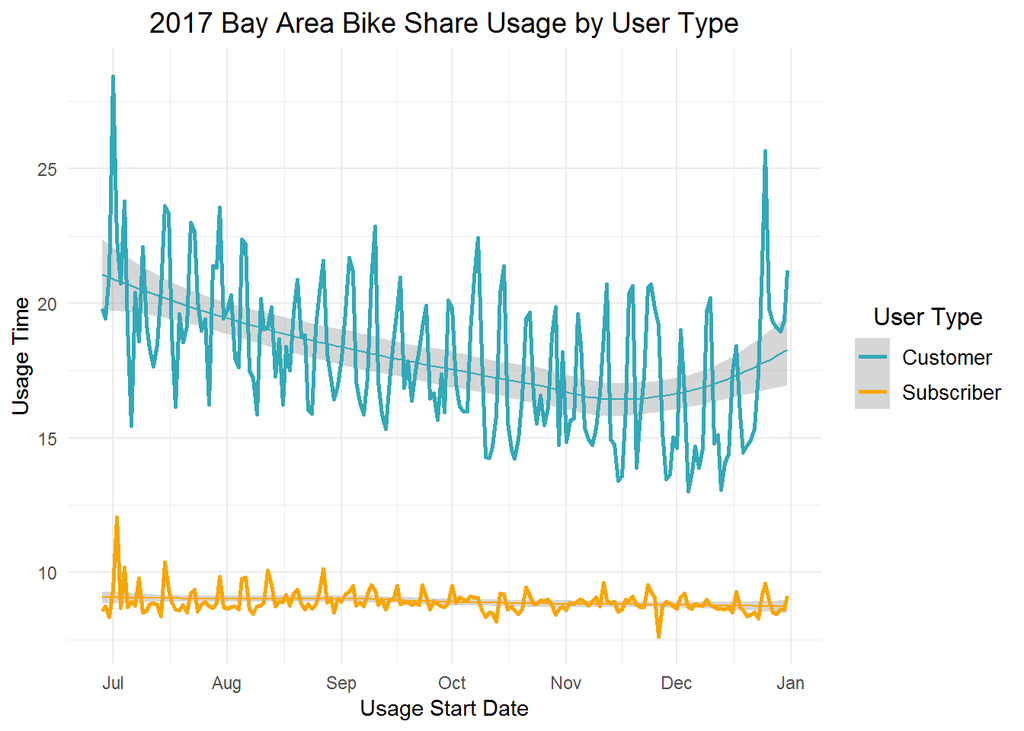

## Open and Closed Murder data

### Load Libraries

```r
library(readr)
library(tidyverse)
library(sf)
library(ggplot2)
library(ggpubr)
library(viridis)
library(DT)
```

### The Analysis

This analysis will read in murder case data from 28 states and calculate the difference in the percentage of victims who are non-white and who are white in open and closed cases.

A choropleth map is generated with these data and states are colored dark to bright based on the percent difference calculated for open and closed cases.

```r
# -- load in homicide data and tidy up data frame
df <- read_csv('https://raw.githubusercontent.com/washingtonpost/data-homicides/master/homicide-data.csv')
```

```r
df <- as_tibble(transform(df, reported_date = as.Date(as.character(df$reported_date), format = '%Y%m%d')))
df$victim_age <- as.integer(df$victim_age)

# -- wrangle data to get relative percentage of unsolved murders by state and victim race
df_state_open <- df %>%
  filter(disposition == 'Open/No arrest' & victim_race != 'Unknown') %>%
  mutate(victim_race = case_when(
    victim_race == 'White' ~ 'White',
    victim_race != 'White' ~ 'Non-White')) %>%
  group_by(state, victim_race) %>%
  summarize(total = n()) %>%
  mutate(percent = round(total/sum(total)*100, 2))

# -- wrangle data to get relative percentage of closed murders by state and victim race
df_state_closed <- df %>%
  filter(disposition != 'Open/No arrest' & victim_race != 'Unknown') %>%
  mutate(victim_race = case_when(
    victim_race == 'White' ~ 'White',
    victim_race != 'White' ~ 'Non-White')) %>%
  group_by(state, victim_race) %>%
  summarize(total = n()) %>%
  mutate(percent = round(total/sum(total)*100, 2))

# -- get difference in percent between black and white victims for open cases
df_open_diff <- df_state_open %>%
  group_by(state) %>%
  mutate(difference = sum(percent[victim_race == 'Non-White']) - percent[victim_race == 'White']) %>%
  select(state, difference) %>%
  unique()

# -- get difference in percent between black and white victims for closed cases
df_closed_diff <- df_state_closed %>%
  group_by(state) %>%
  mutate(difference = percent[victim_race == 'Non-White'] - percent[victim_race == 'White']) %>%
  select(state, difference) %>%
  unique()

# -- load US map shape file
fifty_location <- "C:/R_journalism/learn-chapter-5-master/static_maps/data/cb_2017_us_state_20m/cb_2017_us_state_20m.shp"
fifty_states <- st_read(fifty_location)
# -- filter out Hawaii, Alaska, and Puerto Rico
lower_48 <- fifty_states %>%
  filter(! NAME %in% c('Hawaii', 'Alaska', 'Puerto Rico'))


######## -- something different to use facet wrap
df_states_open <- left_join(lower_48, df_open_diff, by = c('STUSPS' = 'state'))

df_states_open$disposition <- "Open"

# -- join closed
df_states_closed <- left_join(lower_48, df_closed_diff, by = c('STUSPS' = 'state'))

df_states_closed$disposition <- "Closed"

# -- bind by row
df_states_all <- rbind(df_states_closed,df_states_open)
```

### The Plot

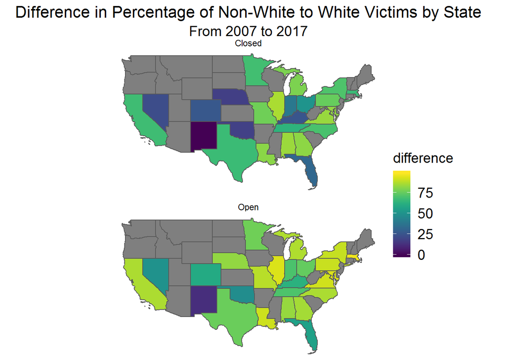